# Do you really know about wine? (A guideline of finding good wines)

This article is covered some interesting findings about wine. Thus, it can use as a reference that helps people to make a better choice when they decide to buy wines.

Information about the dataset: those data are collected from Vivino in February 2020.

```python
%%html
<button onclick="jQuery('.code_cell .input').toggle()">Toggle Code Cells</button>
```

### Question 1: Is the high price means high rating? How are they related?

When people purchase wine at a supermarket, price oftenly plays a significant role in their decision-making process. However, the question arises: does a higher price mean a better quality of wine?

To solve this problem, we will analyze the relationship between wine ratings and their prices.

Firstly, we can calculate the correlation between these two variables, “WineRating” and “WinePrice,” since it is the most obvious method to see if they’re related.

```python
import pandas as pd

file_path = 'white-wine-price-rating.csv'

wine_data = pd.read_csv(file_path)

from scipy import stats

x = wine_data['WineRating']
y = wine_data['WinePrice']

slope, intercept, r_value, p_value, std_err = stats.linregress(x, y)

print(f"Correlation Coefficient: {r_value}")
```

```
Correlation Coefficient: 0.3387388744417564
```

We can see the correlation for this dataset is only 0.34, indicating that there is a slightly positive relationship.

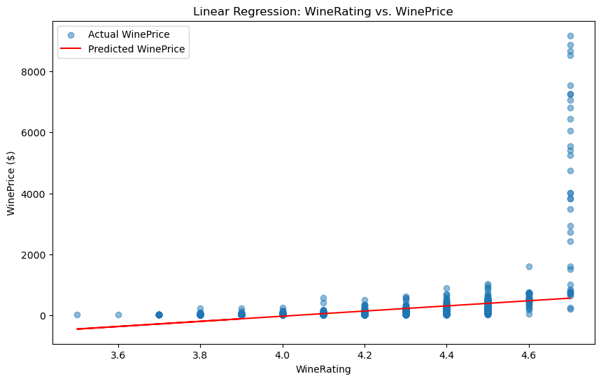

```python
import matplotlib.pyplot as plt
import numpy as np

predicted_y = intercept + slope * x

plt.figure(figsize=(10, 6))

plt.scatter(x, y, alpha=0.5, label='Actual WinePrice')

plt.plot(x, predicted_y, color='red', label='Predicted WinePrice')

plt.title('Linear Regression: WineRating vs. WinePrice')
plt.xlabel('WineRating')
plt.ylabel('WinePrice ($)')
plt.legend()

plt.show()
```

The graph shows a positive correlation between price and rating, particularly for ratings below 4.6. However, for wines with ratings above 4.6, the price variability increases significantly, becoming more erratic. This variability in higher price ranges contributes to a decrease in the overall correlation between price and rating.

The correlation coefficient between wine price and rating is 0.34, which means they have a positive, but not very strong connection. So, a high price doesn't guarantee a top-rated wine, but the price can sometimes point us to a good wine. If we are buying a wine, other factors also need to think about, like brand, availability and so on. Therefore, we might find excellent wines that aren't pricey and some expensive ones that don't live up to their cost. When shopping for wine, please don't just focus on the price, but also consider other qualities too.

### Question 2: Which region has the highest average wine rating, and how does it compare in terms of pricing?

The reason why we want to discuss this question is that it helps us to choose a good wine based on its region of origin.

To solve this problem, we first need to calculate the average wine rating for each region by aggregating individual wine ratings. Next, we rank these averages to determine the region with the highest wine rating.

Here is the table we got:

```python
average_ratings = wine_data.groupby('Region')['WineRating'].mean().reset_index()

ranked_average_ratings = average_ratings.sort_values(by='WineRating', ascending=False).reset_index(drop=True)

display(ranked_average_ratings.head())
```

|  | Region | WineRating |
| --- | --- | --- |
| 0 | Chilean | 4.300000 |
| 1 | Californian | 4.239801 |
| 2 | Argentinian | 4.229630 |
| 3 | Napa Valley | 4.219355 |
| 4 | Burgundy | 4.201898 |

Thus, the region having highest average wine rating is “Chilean” with 4.3 rating.

Then, we do the similar procedure for wine price and get following result:

```python
average_prices = wine_data.groupby('Region')['WinePrice'].mean().reset_index()

ranked_average_prices = average_prices.sort_values(by='WinePrice', ascending=False).reset_index(drop=True)

display(ranked_average_prices.head())
```

|  | Region | WinePrice |
| --- | --- | --- |
| 0 | Burgundy | 181.924496 |
| 1 | Bordeaux | 140.603407 |
| 2 | Californian | 99.136020 |
| 3 | Chilean | 89.650000 |
| 4 | Napa Valley | 80.241613 |

Thus, the region having highest average wine price is “Burgundy” with $ 181.92.

Now, compared to those two tables, we can find out that "Chilean" has a very high rating, while the price of it is only half of “Burgundy”. Even though we cannot say that wines from 'Chilean' are the best choice, we can consider 'Chilean' as a significant reference factor when we are purchasing wines.

### Question 3: For high rating wines, what is common words they used in their name?

```python
from collections import Counter
import re

high_rating_wines = wine_data[(wine_data['WineRating'] >= 4.6) & (wine_data['WineRating'] <= 5.0)]

full_names = high_rating_wines['FullName']

def tokenize(name):
    # Convert to lowercase and remove non-alphabetic characters
    tokens = re.findall(r'\b[a-z]+\b', name.lower())
    return tokens

all_words = [word for name in full_names for word in tokenize(name)]

word_counts = Counter(all_words)

most_common_words = word_counts.most_common(10)

most_common_words_df = pd.DataFrame(most_common_words, columns=['Word', 'Frequency'])

display(most_common_words_df)
```

|  | Word | Frequency |
| --- | --- | --- |
| 0 | domaine | 54 |
| 1 | montrachet | 42 |
| 2 | cru | 42 |
| 3 | grand | 41 |
| 4 | coche | 26 |
| 5 | dury | 26 |
| 6 | de | 20 |
| 7 | les | 19 |
| 8 | la | 13 |
| 9 | conti | 13 |

To visualize it, we can create a word cloud to help us to understand:

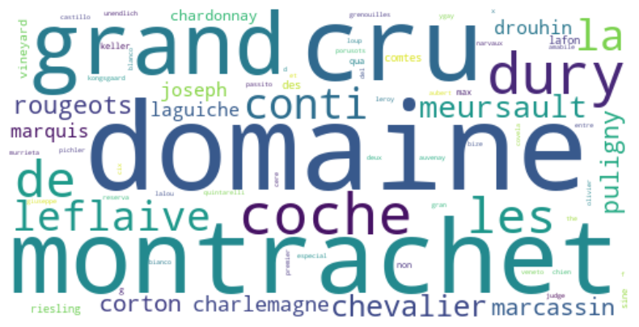

```python
from wordcloud import WordCloud
import matplotlib.pyplot as plt

wordcloud = WordCloud(width=500, height=250, background_color='white').generate_from_frequencies(word_counts)

plt.figure(figsize=(10, 5))
plt.imshow(wordcloud, interpolation='bilinear')
plt.axis('off')
plt.show()
```

We can tell that “Domaine,” “Montrachet,” “cru,” and “grand” has very high frequency to appear. All of those words suggest a strong influence of French wine traditions, classifications, and regions. In that case, if we are purchasing wines, we can try to notice if they include those words.

### Conclusion

Next time, if we want to find some good wines, we can seek assistance from the following methods:

1. We can consider the price of the wine. Although more expensive wines do not necessarily mean they have better reviews, wines that are priced higher generally receive more favorable ratings.
2. When purchasing wine, we can check if the region of origin is 'Chilean,' which could be an indicator of good rating.
3. While looking at the names of wines, we can observe whether they include words like 'Domaine,' 'Montrachet,' 'cru,' and 'grand,' because words are frequently found in high-rated wines.